# Going wild: what a global small-animal tracking system could do for experimental biologists | Journal of Experimental Biology | The Company of Biologists

[figure not shown]

[Volume 210, Issue 2](https://journals.biologists.com/jeb/issue/210/2)

January 2007

[figure not shown]

Article contents

COMMENTARY| 15 January 2007

# Going wild: what a global small-animal tracking system could do for experimental biologists

Martin Wikelski,

Roland W. Kays,

N. Jeremy Kasdin,

Kasper Thorup,

James A. Smith,

George W. Swenson, Jr

Author and article information

*J Exp Biol* (2007) 210 (2): 181–186.

https://doi.org/10.1242/jeb.02629

Article history

## SUMMARY

Tracking animals over large temporal and spatial scales has revealed invaluable and spectacular biological information, particularly when the paths and fates of individuals can be monitored on a global scale. However, only large animals (greater than ∼300 g) currently can be followed globally because of power and size constraints on the tracking devices. And yet the vast majority of animals is small. Tracking small animals is important because they are often part of evolutionary and ecological experiments, they provide important ecosystem services and they are of conservation concern or pose harm to human health. Here, we propose a small-animal satellite tracking system that would enable the global monitoring of animals down to the size of the smallest birds, mammals (bats), marine life and eventually large insects. To create the scientific framework necessary for such a global project, we formed the ICARUS initiative([www.IcarusInitiative.org](http://www.icarusinitiative.org/)),the International Cooperation for Animal Research Using Space. ICARUS also highlights how small-animal tracking could address some of the `Grand Challenges in Environmental Sciences' identified by the US National Academy of Sciences, such as the spread of infectious diseases or the relationship between biological diversity and ecosystem functioning. Small-animal tracking would allow the quantitative assessment of dispersal and migration in natural populations and thus help solve enigmas regarding population dynamics,extinctions and invasions. Experimental biologists may find a global small-animal tracking system helpful in testing, validating and expanding laboratory-derived discoveries in wild, natural populations. We suggest that the relatively modest investment into a global small-animal tracking system will pay off by providing unprecedented insights into both basic and applied nature.

Tracking small animals over large spatial and temporal scales could prove to be one of the most powerful techniques of the early 21st century, offering potential solutions to a wide range of biological and societal questions that date back two millennia to the Greek philosopher Aristotle's enigma about songbird migration. Several of the more recent Grand Challenges in Environmental Sciences, such as the regulation and functional consequences of biological diversity or the surveillance of the population ecology of zoonotic hosts, pathogens or vectors, could also be addressed by a global small-animal tracking system.

Our discussion is intended to contribute to an emerging groundswell of scientific support to make such a new technological system happen.

Keywords:

[small animal](https://journals.biologists.com/jeb/search-results?qb={%22Keywords1%22:%22small+animal%22}), [ICARUS initiative](https://journals.biologists.com/jeb/search-results?qb={%22Keywords1%22:%22ICARUS+initiative%22}), [migration pattern](https://journals.biologists.com/jeb/search-results?qb={%22Keywords1%22:%22migration+pattern%22}), [migratory bird orientation](https://journals.biologists.com/jeb/search-results?qb={%22Keywords1%22:%22migratory+bird+orientation%22}), [satellite](https://journals.biologists.com/jeb/search-results?qb={%22Keywords1%22:%22satellite%22}), [field experiments](https://journals.biologists.com/jeb/search-results?qb={%22Keywords1%22:%22field+experiments%22}), [tracking technology](https://journals.biologists.com/jeb/search-results?qb={%22Keywords1%22:%22tracking+technology%22}), [telemetry](https://journals.biologists.com/jeb/search-results?qb={%22Keywords1%22:%22telemetry%22}), [songbird](https://journals.biologists.com/jeb/search-results?qb={%22Keywords1%22:%22songbird%22}), [bat](https://journals.biologists.com/jeb/search-results?qb={%22Keywords1%22:%22bat%22})

## Applications of a global small animal tracking system

### Songbird movements as an example

Imagine tracking the individual movements of red-billed queleas (*Quelea quelea*) across the African continent(Ward, 1971; Dallimer and Jones, 2002). Queleas are the world's most abundant birds and have a breeding population in excess of 1.5 billion. Single colonies can contain up to 30 million birds and these large individual colonies can destroy up to 5% of grain crops in the Sahel zone of Africa (Bruggers and Elliott,1989). Queleas can migrate long distances, sometimes more than 2000 km, to seek appropriate breeding areas or to avoid food shortage(Ward, 1971). Beyond the obvious applied benefit of planning for human health emergencies such as widespread famines in the present and projected paths of these `feathered locusts' (Manikowski, 1988; Malthus, 1995; Mullie et al., 1999),researchers could also test whether our mechanistic, lab-derived understanding of migratory drivers truly reflects migratory decisions of individuals that join the swarming herds in fields and deserts(Marshall and Disney, 1956; Desdisney et al., 1959; Wolfson and Winchester, 1959; Jones and Ward, 1976). Although it remains unclear whether a mechanistic knowledge of quelea movement would enable agricultural managers to prevent major devastations from the outset (Manikowski, 1988),tracking individuals might at least allow for a predictive forecast of pattern, similar to a tornado or hurricane warning system(Malthus, 1995).

## The power of combined laboratory and field experiments

| Scientific question | Basis of current knowledge | Possibilities in the ICARUS project |
| --- | --- | --- |
| Experimental approaches |  |  |
| The migratory orientation program in birds | Simple experiment using ring recoveries of displaced common starlings(Perdeck, 1958) | New model species (marsh warbler, Swainson's thrush). Has been tried on larger species |
| Cue use in orientation of migratory birds | With few exceptions (e.g. Cochran et al.,2004), decades of orientation tests in Emlen funnels | Certainty of studying the behavior at large scales in the wild on many continents |
| Non-experimental approaches |  |  |
| Basic migration patterns, e.g. route and wintering areas of long-ranging animals | Band recoveries and observations | Identifying wintering areas for endangered species, e.g. aquatic warbler |
| Dispersal | Observations of dispersal distances or recaptures of marked individuals, both of which are typically spatially biased | Unbiased tracking of dispersal movements |
| Mortality | Mortality at different parts of the life cycle are extremely difficult to obtain in populations where individuals cannot be followed | Spatially unbiased quantification of deaths at different stages of the life cycle, i.e. on migration and in wintering areas |
| Maximum flight distance | Mostly based on wind tunnel studies and theory | Observations of migrations by wild birds suggest that much longer distances than the ones estimated from tunnel studies are possible |
| Effects of climate and land use changes on migration patterns | Observations | The detailed paths obtained will make it possible to measure these effects in real time |
| Seed dispersal | Genetic and morphological studies | Direct tracking of radio-tagged seeds around the world |

## A global challenge for experimental biologists: dispersal and long-distance migration

Migrating animals pose the most extreme challenge in animal tracking(Cochran, 1972), but even repeatedly locating resident study animals is rarely easy(Winkler et al., 2004). Many animal species are cryptic, shy and faster than the field biologists chasing after them. Nevertheless, there are many situations in nature where this is not true, and experimental biologists have taken advantage of this. The bonanza of knowledge that these situations have produced illustrates the scientific potential of a global tracking system. The Galapagos are one such example where animal dispersal is limited. The extraordinary success of Rosemary and Peter Grant's long-term investigation on Darwin's finches(Grant and Grant, 1996) relies on the ability to reliably relocate individuals, enabled because they work on birds living on a small, desolate crater island 1000 km off the Pacific coast of South America. In most other `open' study systems, the demonstration of microevolutionary processes would have been much more equivocal.

The only reliable approach for animal tracking with guaranteed global coverage and constant access is *via* satellite. Present satellite technology allows us to track large (>300 g) animals globally and has led to spectacular insights. Weimerskirch et al. tracked wandering albatrosses(*Diomedea exulans*) around the South Pole and through the Indian Ocean and related their wanderings to feeding rates and food distribution(Weimerskirch et al., 1993). Fuller and colleagues found a breeding snowy owl in Alaska one year, then in Canada and in Siberia in subsequent years(Fuller et al., 2003),presumably also breeding at these locations. Block and coworkers tracked bluefin tuna across the entire Atlantic and into the Mediterranean Sea(Block et al., 2005). Although all of these studies are remarkable, many large animals such as petrels or albatrosses may outlive their researchers(Clapp and Sibley, 1966) and thus do not allow for evolutionary trends to be observed. Similarly, for many experimental studies, large animals are not ideally suited as they are either endangered and protected, not numerous enough, again too long-lived or simply too difficult to keep in any numbers to study selection on certain traits.

## Beyond Aristotle's migration enigma: tracking small animals globally

We suggest here that tracking small mobile animals will solve some of the longest-standing biological enigmas across a range of disciplines and provide a much sought-after tool for experimental biologists of all fields (e.g. Pennycuick, 1969; Hedenström and Alerstam,1997; Klaassen et al.,2000). Aristotle wondered about 2000 years ago where songbirds disappeared to in winter (Peck,1968). For many of the species that the famous natural philosopher was concerned about, we are still rather ignorant - even in Europe, where scientific bird banding started more than 100 years ago(Berthold, 2001). For most of the species wintering in tropical areas, our knowledge about wintering homes and migration routes is limited to less than a handful of recoveries in the presumed wintering areas and the information contained in the recordings of observers (Thorup and Rahbek,2004).

Fig. 1.

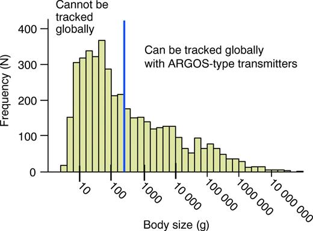

Other questions for biologists that such new satellite tracking methods could address are natal dispersal (Winkler et al., 2004), a mechanism critical to our understanding and modeling of animal demography (Lawton and May, 1983), metapopulation dynamics(Robinson et al., 1995),life-history evolution (Sillett and Holmes, 2002) and extinction(Jackson, 1979; Webster et al., 2002). For example, it is unknown whether the fragmented landscapes of the North American Midwest are population sinks for wood thrushes or whether these long-distance migratory songbirds sustain healthy populations amidst the corn and soybean fields, despite high nest predation(Robinson et al., 1995). Long-term tracking over large spatial scales could be used to discover when and where free-ranging animals die, helping to improve our understanding of the ecology of the different life-cycle stages that are otherwise very difficult to investigate (Rubenstein et al., 2002). Furthermore, the paths of birds, bats, rodents and insects carrying diseases could be followed(Rappole et al., 2000; Malkinson et al., 2002).

What is needed to address these problems is a system that can track hundreds of small animals down to the size of a 6 g hummingbird or large insects (Naef-Daenzer et al.,2005; Wikelski et al.,2006) over large, continental distances and over long periods of time. Individuals should be tracked over at least one entire year to solve pressing scientific and conservation questions, such as where individuals die and what stopover sites are most important(Moore and Simons, 1992; McNamara et al., 1998; Moore, 2000; Sillett and Holmes, 2002).

## Why current technology is not sufficient

Various new technologies or combinations of already existing technologies could theoretically provide the means to fulfill these science requirements,although each has its own series of hurdles to overcome before meeting our scientific needs. For example, to understand the connectivity between breeding and wintering grounds, a combination of genetic, isotopic and banding studies could provide significant insights(Rubenstein et al., 2002). However, the spatial precision of these methods is inherently limited(Rubenstein and Hobson, 2004)and the actual routes that animals take during migration would remain unknown. Satellite tracking systems such as ARGOS([www.argosinc.com](http://www.argosinc.com/))have produced spectacular global location data for large animals, for example albatrosses (Weimerskirch et al.,1993). ARGOS instruments are housed on board different satellites from the US National Oceanic and Atmospheric Administration, The Japanese Space Agency and the European Meteorological Satellite organization. Two satellites are operational at any time in ∼850 km orbits. The ARGOS system collects data from Platform Terminal Transmitters (PTTs) and delivers telemetry data directly to the users. PTT satellite tags may be shrunk down to smaller sizes in the future but will be unlikely to surpass a lower size limit of 5-8 g. GPS (Global Positioning System) tags are now approaching 5-10 g(Lipp et al., 2004; [www.technosmart.edu](http://www.technosmart.edu/)),but these tags often need to be recovered to read out the positions and they still remain too large for most animals. GPS tags with a communication network to transmit data are even heavier (30 g; [www.microwavetelemetry.com](http://www.microwavetelemetry.com/)). Miniaturizing cell-phone technology holds high promises but also high hurdles. The hardware and software (including >1 million lines of code) are advanced and inexpensive to purchase but very customized to commercial applications. It is unclear to what degree a small market such as experimental biology can capitalize on this technology. Furthermore, network coverage remains limited on a global scale and locational accuracy is low(Stokely, 2005). Radar technology, either passive or active, also holds many promises but, because of the immobility of most radar installations, will not resolve long-distance migration of individuals (passive radar)(Gauthreaux and Belser, 2003). Active radar, such as the cross-band transponder technology, faces similar power and detection problems as the ARGOS satellite tags([www.earthspan.org](http://www.earthspan.org/)).

## A global solution to track small animals

All long-distance tracking problems boil down to constraints in the emitted signal power of animal-borne tags and the detection of these weak signals against background noise (Cochran and Wikelski, 2005). These problems are not unique to animal tracking. Another scientific discipline has already addressed similar, albeit inverse,problems. As radio astronomers cannot increase the power emitted by distant galaxies or control the nature of the radio emissions, they were forced to build sensitive receivers with sophisticated antennae and to develop elaborate signal processing algorithms (e.g. Kraus,1986; Thompson et al.,1986). We suggest that the best technical solution for experimental biologists involves a similar solution(Cochran and Wikelski, 2005; Cochran and Wikelski, 2005). Radio astronomers point antennas into space to locate faint radio sources against background noise tens of thousands of times stronger. Wildlife biologists could point antennas towards earth from near-earth orbit to locate small radio transmitters attached to animals. Radio telemetry receivers and antennas mounted on satellites have global reach and are a natural extension of the ground and aerial radio techniques that have been the mainstay of animal tracking for the past 45 years(Lord et al., 1962). Extending this space technology to accommodate much smaller animals than can be served by the ARGOS program will have very great benefits to the study of dispersal and migration.

The physics of this scenario has been modeled and shown to provide a workable solution using presently available radio technology. Satellite-mounted radio receivers could track radio-tags with a radiated power as low as 1 mW with an accuracy of a few km under favorable conditions. This power can be achieved by modern tags as small as <1 g, which could be carried by, for example, migrating birds, bats, rodents, marine life or even desert insects. In the marine realm, radio transmitters could not be received in space when animals are below the surface, but a satellite system could work for surfacing animals or with the help of pop-up archival tags(Block et al., 2005). The remote measurement of physiological parameters characterizing the state of animals could be added to any of these tags(Cooke et al., 2004; Bowlin et al., 2005).

## ICARUS can make a small-animal tracking satellite fly

Given the potential for this empowering technology to transform our understanding of the natural world, we have formed a global initiative to support its deployment: the International Cooperation for Animal Research Using Space (ICARUS; [www.icarusinitiative.org](http://www.icarusinitiative.org/)). We propose to employ radio technology on a near-earth orbit satellite (to be deployed) to track small animals around the globe. Within this framework, one possible actual satellite design is already being considered(www.icarusinitiative.org/solutions). The benefits of such a system seem obvious to scientists, but many hurdles remain to convince funding agencies and politicians that such an effort is worth the investment (50-100 million US$) required to build and launch a satellite. This paper represents a start at this task, highlighting a number of age-old questions about the natural world that such a system could solve and why they are broadly important in basic and applied ways. We encourage experimental biologists to consider how global tracking could help address their research needs and together create the scientific groundswell to make ICARUS fly.

## Acknowledgements

This study was partially supported by NSF RCN (MIGRATE), the National Geographic Society and the Peninsula Foundation (Frank Levinson). We also thank Princeton University, the Danish Natural Science Council and the Smithsonian Tropical Research Institute for support.

## References

**Alerstam, T. and Hedenström, A.** (

1998

). Optimal migration.

J. Avian Biol.

29

,

339

-340.

**Bartholomew, G. A.** (

1986

). The role of natural history in contemporary biology.

Bioscience

3

,

324

-329.

**Bennett, P. M. and Owens, I. P. F.** (

2002

).

Evolutionary Ecology of Birds: Life Histories, Mating Systems and Extinction

. New York: Oxford University Press.

**Berthold, P.** (

2001

).

Bird Migration:A General Survey

. New York: Oxford University Press.

**Block, B. A., Teo, S. L. H., Walli, A., Boustany, A.,Stokesbury, M. J. W., Farwell, C. J., Weng, K. C., Dewar, H. and Williams, T. D.** (

2005

). Electronic tagging and population structure of Atlantic bluefin tuna.

Nature

434

,

1121

-1127.

**Bowlin, M. S., Cochran, W. W. and Wikelski, M.**(

2005

). Biotelemetry of New World thrushes during migration:physiology, energetics and orientation in the wild.

Integr. Comp. Biol.

45

,

295

-304.

**Bruggers, R. L. and Elliott, C. C. H.** (

1989

).

Quelea quelea, Africa's Bird Pest

. Oxford: Oxford University Press.

**Clapp, R. B. and Sibley, F. C.** (

1966

). Longevity records of some central Pacific seabirds.

Bird Banding

38

,

193

-197.

**Cochran, W. W.** (

1972

). Long-distance tracking of birds. In

Animal Orientation and Navigation

(ed. K. Schmidt-Koenig, G. J. Jacobs, S. R. Galler and R. E. Belleville), pp.

39

-59. Washington, DC: US Government Printing Office.

**Cochran, W. W.** (

1987

). Orientation and other migratory behaviors of a Swainson's Thrush followed for 1500 km.

Anim. Behav.

35

,

927

-929.

**Cochran, W. W. and Wikelski, M.** (

2005

). Individual migratory tactics of New World *Catharus* thrushes: current knowledge and future tracking options from space. In

Birds of Two Worlds

(ed. P. Marra and R. Greenberg), pp.

274

-289. Princeton: Princeton University Press.

**Cochran, W. W., Mouritsen, H. and Wikelski, M.**(

2004

). Migrating songbirds recalibrate their magnetic compass daily from twilight cues.

Science

304

,

405

-408.

**Cooke, S. J., Hinch, S. G., Wikelski, M., Andrews, R. D.,Kuchel, L. J., Wolcott, T. G. and Butler, P. J.** (

2004

). Biotelemetry: a mechanistic approach to ecology.

Trends Ecol. Evol.

19

,

335

-343.

**Cryan, P. M., Bogan, M. A., Rye, R. O., Landis, G. P. and Kester, C. L.** (

2004

). Stable hydrogen isotope analysis of bat hair as evidence for seasonal molt and long-distance migration.

J. Mammal.

85

,

995

-1001.

**Dallimer, M. and Jones, P. J.** (

2002

). Migration orientation behaviour of the red-billed quelea *Quelea quelea.*

J. Avian Biol.

33

,

89

-94.

**Desdisney, H. J., Lofts, B. and Marshall, A. J.**(

1959

). Duration of the regeneration period of the internal reproductive rhythm in a Xerophilous equatorial bird, *Quelea quelea.*

Nature

184

,

1659

-1660.

**Diehl, R. H. and Larkin, R. P.** (

1998

). Wing beat frequency of *Catharus* thrushes during nocturnal migration,measured via radio telemetry.

Auk

115

,

591

-601.

**Fuller, M. R., Holt, D. and Schueck, L. S.**(

2003

). Snowy owl movements: variation on the migration theme. In

Avian Migration

(ed. P. Berthold, E. Gwinner and E. Sonnenschein), pp.

359

-366. Heidelberg:Springer.

**Gagliardo, A., Ioalé, P. and Bingman, V. P.**(

1999

). Homing in pigeons: the role of the hippocampal formation in the representation of landmarks used for navigation.

J. Neurosci.

19

,

311

-315.

**Gagliardo, A., Ioalè, P., Savini, M. and Wild, J. M.**(

2006

). Having the nerve to home: trigeminal magnetoreceptor *versus* olfactory mediation of homing in pigeons.

J. Exp. Biol.

209

,

2888

-2892.

**Gauthreaux, S. A. and Belser, C. G.** (

2003

). Radar ornithology and biological conservation.

Auk

120

,

266

-277.

**Grant, P. R. and Grant, B. R.** (

1996

). Speciation and hybridization in island birds.

Philos. Trans. R. Soc. Lond. B Biol. Sci.

351

,

765

-772.

**Hedenström, A. and Alerstam, T.** (

1997

). Optimum fuel loads in migratory birds: distinguishing between time and energy minimization.

J. Theor. Biol.

189

,

227

-234.

**Jackson, J. A.** (

1979

). Insectivorous birds and North American forest ecosystems. In

The Role of Insectivorous Birds in Forest Ecosystems

(ed. J. G. Dickinson, R. N. Connor, R. R. Fleet, J. A. Jackson and J. C. Kroll), pp.

1

-7. New York: Academic Press.

**Jones, P. J. and Ward, P.** (

1976

). Level of reserve protein as proximate factor controlling timing of breeding and clutch-size in red-billed quelea *Quelea quelea.*

Ibis

118

,

547

-574.

**Klaassen, M., Kvist, A. and Lindström, Å.**(

2000

). Flight costs and fuel composition of a bird migrating in a wind tunnel.

Condor

102

,

444

-451.

**Kraus, J. D.** (

1986

).

Radio Astronomy

. Powell: Cygnus-Quasar Books.

**Lawton, J. H. and May, R. M.** (

1983

). The birds of Selbourne.

Nature

306

,

732

-733.

**Lipp, H. P., Vyssotski, A. L., Wolfer, D. P., Renaudineau, S.,Savini, M., Troster, G. and Dell'Omo, G.** (

2004

). Pigeon homing along highways and exits.

Curr. Biol.

14

,

1239

-1249.

**Lord, R. D., Bellrose, F. C. and Cochran, W. W.**(

1962

). Radio telemetry of the respiration of a flying duck.

Science

137

,

39

-40.

**Malkinson, M., Banet, C., Weisman, Y., Pokamunski, S., King, R.,Drouet, M. T. and Deubel, V.** (

2002

). Introduction of West Nile virus in the Middle East by migrating white storks.

Emerg. Infect. Dis.

8

,

392

-397.

**Malthus, T.** (

1995

). Mapping and monitoring of *Quelea* habitats in East-Africa.

Int. J. Geogr. Inf. Syst.

9

,

650

.

**Manikowski, S.** (

1988

). Aerial spraying of Quelea.

Trop. Pest Manag.

34

,

133

-140.

**Marshall, A. J. and Disney, H.** (

1956

). Photostimulation of an equatorial bird (*Quelea quelea*, Linnaeus).

Nature

177

,

143

-144.

**McNamara, J. M., Welham, R. K. and Houston, A. I.**(

1998

). The timing of migration within the context of an annual routine.

J. Avian Biol.

29

,

416

-423.

**Moore, F. R.** (

2000

).

Stopover Ecology of Nearctic-Neotropical Landbird Migrants: Habitat Relations and Conservation Implications

. Lawrence: Allen Press.

**Moore, F. R. and Simons, T. R.** (

1992

). Habitat suitability and stopover ecology of Neotropical landbird migrants. In

Ecology and Conservation of Neotropical Migrant Landbirds

(ed. J. M. Hagan, III and D. W. Johnston), pp.

345

-355. Washingon, DC: Smithsonian Institution Press.

**Muheim, R., Moore, F. R. and Phillips, J. B.**(

2006

). Calibration of magnetic and celestial compass cues in migratory birds - a review of cue-conflict experiments.

J. Exp. Biol.

209

,

2

-17.

**Mullie, W. C., Diallo, A. O., Gadji, B. and Ndiaye, M. D.**(

1999

). Environmental hazards of mobile ground spraying with cyanophos and fenthion for Quelea control in Senegal.

Ecotoxicol. Environ. Saf.

43

,

1

-10.

**Murray, D. L. and Fuller, M. R.** (

2000

). A critical review of the effects of marking on the biology of vertebrates. In

Research Techniques in Animal Ecology

(ed. F. T. Boitani L), pp.

15

-64. New York: Columbia University Press.

**Naef-Daenzer, D. F., Stalder, M., Wetli, P. and Weise, E.**(

2005

). Miniaturization (0.2 g) and evaluation of attachment techniques of telemetry transmitters.

J. Exp. Biol.

208

,

4063

-4068.

**National Academy of Sciences** (

2001

).

Grand Challenges in Environmental Sciences

. Washington, DC: National Academies Press.

**Peck, A. L.** (

1968

).